# Analysis March 2023

Author

The Snail Team

Published

March 22, 2023

## Power Reporting

RQ1: What is the norm when it comes to conducting and reporting statistical power analysis?

- **No mention** of statistical power at all;
- **Mentioned** power but no power analysis;
- **Post-hoc** power analysis;
- **Sensitivity** power analysis: Using the obtained sample size to estimate detectable effect size or power;
- **A priori/Prospective power analysis**: Estimating the required sample size for a chosen effect size

The three figures below display the distribution of power analysis reporting for the whole sample (Figure 1), by journal (Figure 2), and across time (Figure 3) .

### Overall

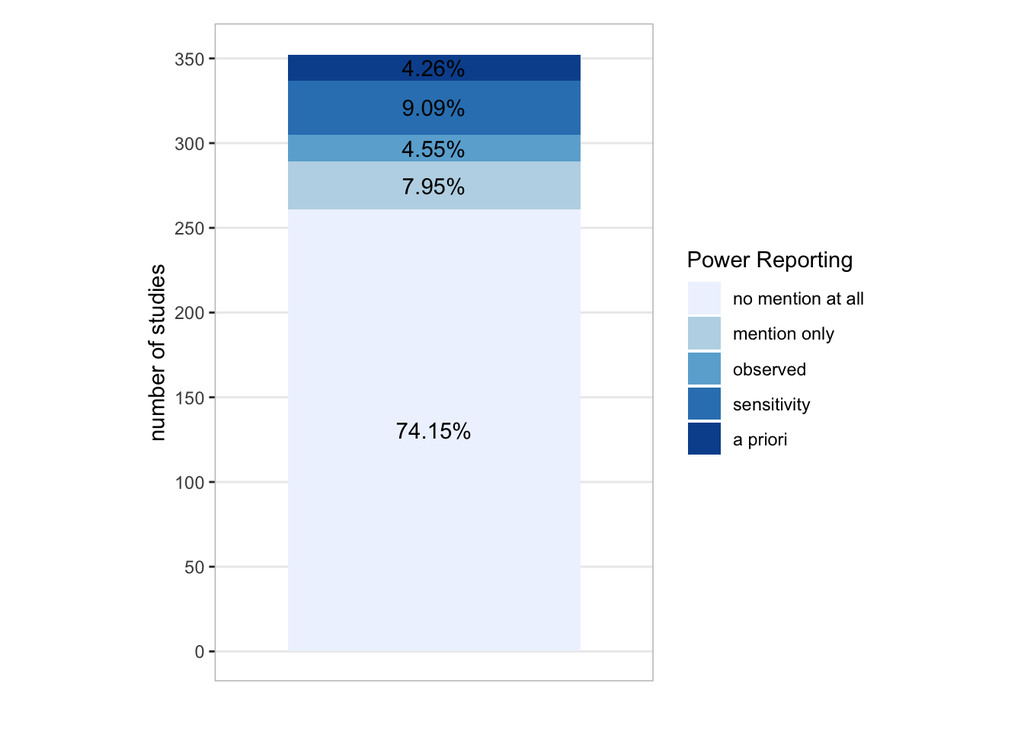

Figure 1: Reporting of power analysis

```r
power.report <- data %>%
  group_by(pmention) %>%
  dplyr::summarize(count = n()) %>%
  mutate(percent = round(count/sum(count) * 100, 2))

### Creating a one-bar plot
ggplot(power.report, aes(x = "", y = count, fill = factor(pmention))) +
  geom_bar(width = 0.8, stat = "identity",
           position = position_stack(reverse = TRUE)) +
  geom_text(aes(label = percent(percent/100)),
            position = position_stack(vjust = 0.5, reverse = TRUE),
            color = "black") +
  scale_fill_brewer(labels = c("no mention at all", "mention only", "observed",
                               "sensitivity", "a priori")) +
  labs(x = "", y = "number of studies") +
  scale_x_discrete(breaks = NULL) +
  scale_y_continuous(limits = c(0, 353), n.breaks = 8) +
  guides(fill = guide_legend(title = "Power Reporting")) +
  theme_bw() +
  theme(panel.grid.minor = element_blank(), axis.ticks.x = element_blank(),
        panel.border = element_rect(colour = "grey")) +
  force_panelsizes(rows = unit(4.5, "in"), cols = unit(3, "in"))
```

### By journal

Similar patterns across journals

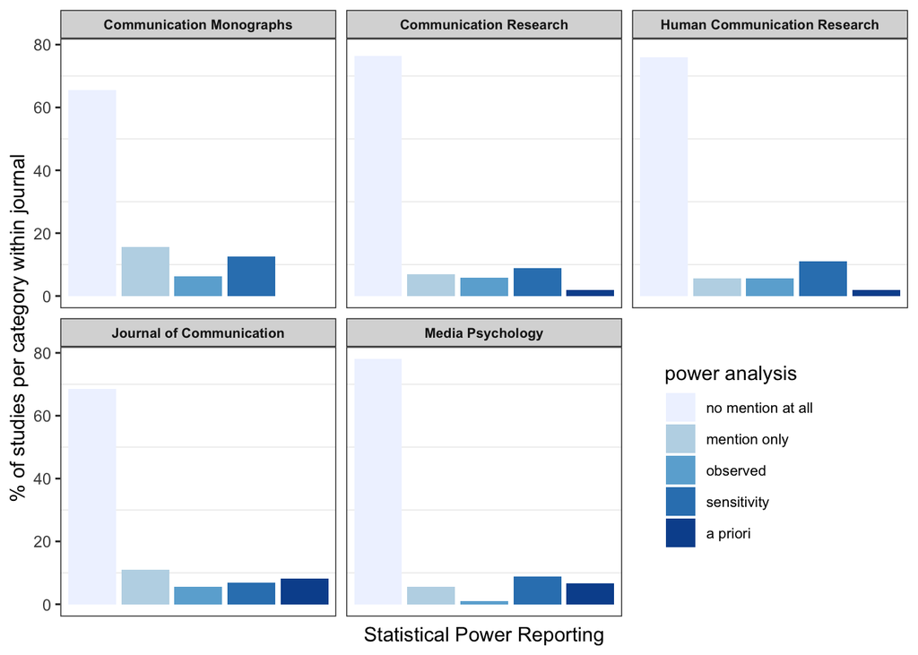

Figure 2: Reporting of power analysis by journals

```r
power.report.j <- data %>%
  group_by(journal, pmention) %>%
  dplyr::summarize(count = n())

power.report.j1 <- transform(power.report.j,
                             percent = ave(count, journal,FUN = prop.table)*100)

ggplot(power.report.j1,
       aes(x = factor(pmention), y = percent, fill = factor(pmention))) +
  geom_bar(stat = "identity") + labs(fill = "power analysis") +
  xlab("Statistical Power Reporting") +
  ylab("% of studies per category within journal") +
  scale_fill_brewer(labels = c("no mention at all",
                               "mention only",
                               "observed", "sensitivity", "a priori")) +
  facet_wrap(~journal) +
  theme_bw() +
  theme(plot.title = element_text(hjust = 0.5, size = 10)) +
  theme(strip.text = element_text(face = "bold", size = 7.5)) +
  theme(legend.text = element_text(size = 8)) +
  theme(legend.position = c(0.9, 0.1), legend.justification = c(1, 0)) +
  theme(panel.grid.major = element_blank(), axis.text.x = element_blank(),
        axis.ticks.x = element_blank())
```

### Across time

The upward trend for a priori power analysis in the last decade is a positive sign.

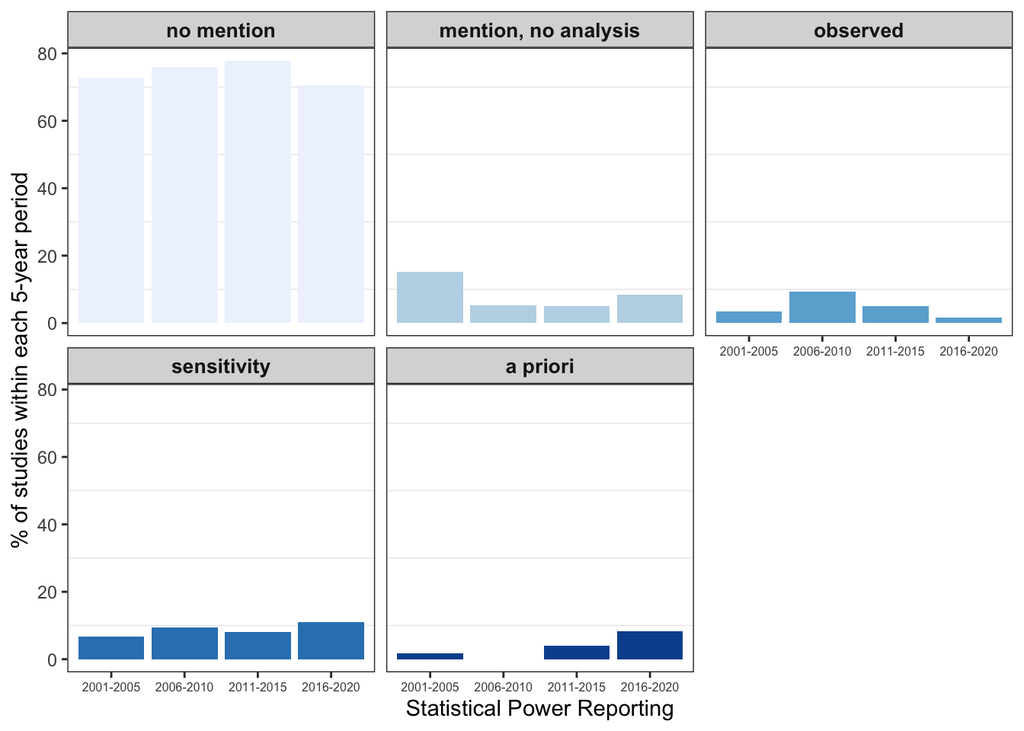

Figure 3: Reporting of power analysis across time

```r
power.report.y <- data %>%
    group_by(fiveyear, pmention) %>%
    dplyr::summarize(count = n())

power.report.y1 <- transform(power.report.y, percent = ave(count, fiveyear,
     FUN = prop.table) * 100)

ggplot(data = power.report.y1,
       aes(x = fiveyear, y = percent, fill = factor(pmention))) +
    geom_bar(stat = "identity", show.legend = FALSE) +
    xlab("Statistical Power Reporting") +
    ylab("% of studies within each 5-year period") +
    scale_fill_brewer() +
    facet_wrap(~pmention,
               labeller = labeller(pmention = c(`0` = "no mention",
                                                `1` = "mention, no analysis",
                                                `2` = "observed",
                                                `3` = "sensitivity",
                                                `4` = "a priori"))) +
    theme(legend.position = "none") +
    theme_bw() +
    theme(axis.text.x = element_text(size = 6)) +
    theme(plot.title = element_text(hjust = 0.5, size = 10)) +
    theme(strip.text = element_text(face = "bold", size = 10)) +
    theme(panel.grid.major = element_blank())
```

## Estimating the Overall Power

RQ2: How much power would the ensemble of our experimental research have to detect effect sizes that could be reasonably expected?

Our analysis is ….

- limited to between-subjects designs
- a “sensitivity power analysis” [^1]:
  - not “the” power it had;
  - but an estimate of the general level of power for this collection of studies
    - given each study’s sample size
    - assuming an effect size

### The decision-making process

Such an analyses involves a few decisions–

1. *what effect sizes to assume*

We consulted these existing benchmarks:

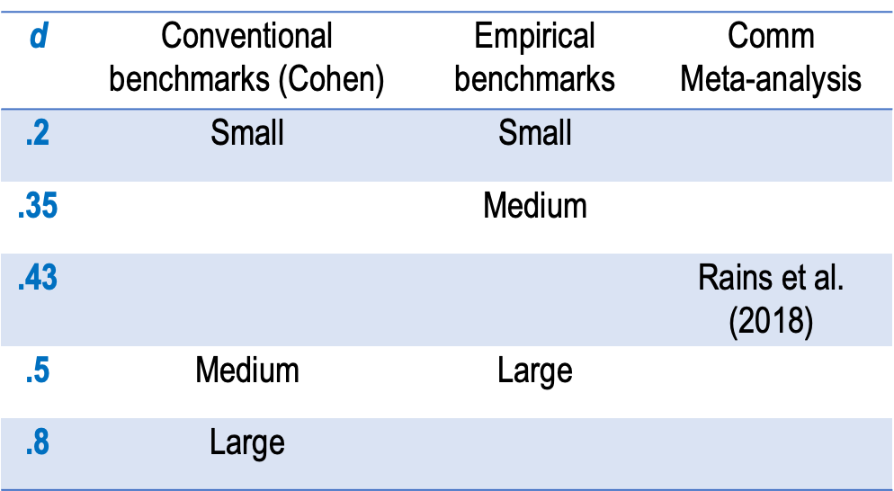

We decided to use the range of ESs as shown below, which included the empirically-derived benchmarks (Schäfer and Schwarz 2019) and the average effect size from the meta-meta-analysis of communication research (Rains, Levine, and Weber 2018), as is shown below. The empirical benchmarks were based on a random selection of 93 preregistered studies across different sub-disciplines of psychology [Schäfer and Schwarz (2019)][^2].

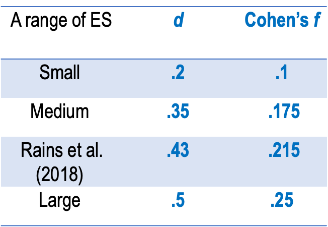

2. *what study design to assume*

In previous assessments like this, an independent-sample, 2-tailed t-test is assumed across the board (e.g., (Elson and Przybylski 2017), (Fraley and Vazire 2014), (Nuijten et al. 2020)). Such an oversimplification would gloss over the basic differences in experimental design such as the number of experimental factors, and the estimate so derived would be too crude an assessment. Our sample, as Table 1 shows, had more than half of the studies with a two-way or higher-order design.

```r
data$nf <- data$factor  #nf: # of factors
data %>%
    filter(nf >= 1) %>%
    group_by(nf) %>%
    summarise(count = n()) %>%
    mutate(percent = round(count/sum(count) * 100, 2)) %>%
    adorn_totals("row") %>%
    flextable() %>%
    set_header_labels(nf = "# of exp factors") %>%
    align(j = ~nf, align = "center") %>%
    autofit
```

Table 1: Number of experimental factors

| # of exp factors | count | percent |
| --- | --- | --- |
| 1 | 145 | 45.17 |
| 2 | 142 | 44.24 |
| 3 | 29 | 9.03 |
| 4 | 5 | 1.56 |
| Total | 321 | 100.00 |

For a primary study, effect size is calibrated given the experimental design and power is estimated accordingly. We therefore decide to take into consideration three basic designs as prototypical scenarios for effect size calibration and power estimation, as is shown below:

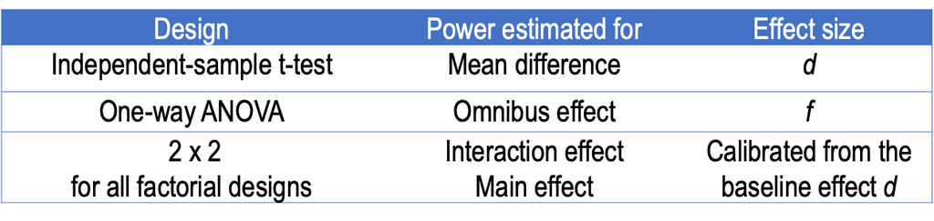

### Power estimate by design

We created three subsets of data:

```r
# data subsets for different designs:
data.2cell <- subset(data, b_cells_adjust == 2)  #two-group only
data.1way <- subset(data, factor == 1 & b_cells_adjust > 2)  #one-way multiple groups
data.2way <- subset(data, factor > 1)  #factorial designs
```

1. Two-group design (n = 83)
2. One-way multi-group design (n = 62)
3. Factorial design (n = 176)

#### 2-group design

```r
## Step 2a: write a function to run power analysis for a 2-group design
## with d as an input, and using the `pwr` package

power.2cell <- function(d) {
  power.estimate <- pwr.t.test(n = data.2cell$n_cell, d = d, sig.level = 0.05,
                               type = "two.sample")  # run `pwr` power analysis
  power.results.frame <- data.frame(data.2cell$n_cell, data.2cell$jid, data.2cell$area,
                                    powerper = sprintf("%.2f%%", power.estimate$power * 100),
                                    power = round(power.estimate$power, 2))  #store results
  return(power.results.frame$power)
}

# Step 2b: run the function to get power for different d
d.2 <- power.2cell(0.2)
d.35 <- power.2cell(0.35)
d.43 <- power.2cell(0.43)
d.5 <- power.2cell(0.5)

# Step 2c: then create a data frame
# and create a stacked data set with d as a variable

df.power.2cell <- data.frame(d.2, d.35, d.43, d.5)
head(df.power.2cell)
range(df.power.2cell)

# stack up data so that d becomes a factor
data.2cell.power <- stack(df.power.2cell)
data.2cell.power <- data.2cell.power %>%
  mutate(d = recode(ind,
                    d.2 = "d=.2",
                    d.35 = "d=.35",
                    d.43 = "d=.43",
                    d.5 = "d=.5"))
data.2cell.power$power <- data.2cell.power$values
data.2cell.power

# Step 2d: creating graph
# first, a ridgeplot
ridge.2cell <- data.2cell.power %>% #creating a ridgeplot
  ggplot(aes(x = power, y = d, fill = factor(after_stat(quantile)))) +
  stat_density_ridges(geom = "density_ridges_gradient",
                      calc_ecdf = TRUE, quantiles = 4,
                      quantile_lines = TRUE, alpha = 0.8, scale = 0.9) +
  scale_x_continuous(breaks = seq(0, 1, 0.25), limits = c(0, 1)) +
  scale_fill_brewer(name = "Quartiles") +
  scale_size_manual(values = c(0.5, 1), guide = "none") +
  labs(y = "", x = "Power") +
  geom_vline(xintercept = 0.8, linetype = "dashed",
             color = "blue", linewidth = 0.8) +
  theme_bw() + theme(legend.position = c(0.92, 0.1)) +
  theme(axis.ticks.y = element_blank(),
        axis.ticks.x = element_blank()) +
  theme(legend.key.size = unit(0.8, "line")) +
  theme(legend.title = element_text(size = 8),
        legend.text = element_text(size = 8),
        axis.text.y = element_blank())


#second, a boxplot
bp.2cell <- ggplot(data.2cell.power, aes(x = d, y = power)) + #creating a boxplot
  geom_point(alpha = 0.2, position = position_jitter(width = 0.1)) +
  geom_boxplot(width = 0.4, alpha = 0.2, fill = NA, outlier.shape = NA) +
  stat_summary(fun = "mean", geom = "point",
               shape = 2, size = 3, color = "blue") +
  scale_size_manual(values = c(0.5, 1), guide = "none") + coord_flip() +
  labs(x = "", y = "Power") + geom_hline(yintercept = 0.8, linetype = "dashed",
                                         color = "blue", linewidth = 0.8) +
  theme_bw() + theme(axis.title.y = element_blank(),
                     axis.ticks.y = element_blank(),
                     axis.text.y = element_text(face = "bold",
                                                color = "blue", size = 12))
```

The median power for the range of ESs (k = 83):

Power estimates for studies with the two-group design

| $d$ | Median | Range |
| --- | --- | --- |
| .2 | 0.21 | 0.08, 0.69 |
| .35 | 0.51 | 0.13, 0.99 |
| .43 | 0.69 | 0.17, 1 |
| .5 | 0.81 | 0.22, 1 |

Figure 4 displays the distribution of statistical power, estimated using the `pwr` package, assuming a two-tailed independent-sample t-test and $\alpha$ of .05.

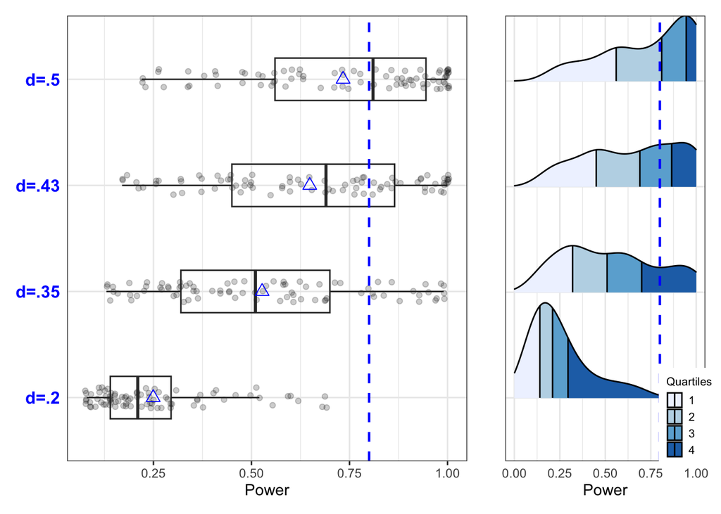

Figure 4: Distribution of power estimates for 2-cell design studies

```r
# combining the two
bp.2cell + ridge.2cell + plot_layout(ncol = 2, widths = c(2, 1))
```

#### One-way multi-group design

```r
## -- Step 3: Power analysis for one-way multi-group design -----
## Power is estimated for the omnibus one-way

## Step 3a: write a function to run power analysis for the one-way anova omnibus test
## with f as an input, and using the `pwr` package

power.1way <- function(f) {
  power.estimate <- pwr.anova.test(k = data.1way$b_cells_adjust,
                                   n = data.1way$n_cell,
                                   f = f, sig.level = 0.05)
  power.results.frame <- data.frame(data.1way$n_cell, data.1way$jid, data.1way$area,
                                    powerper = sprintf("%.2f%%", power.estimate$power * 100),
                                    power = round(power.estimate$power, 2))  #store results
  return(power.results.frame$power)
}

## Step 3b: run the function to get power for different fs
d.2.1w <- power.1way(0.1)
d.35.1w <- power.1way(0.175)
d.43.1w <- power.1way(0.215)
d.5.1w <- power.1way(0.25)

# Step 3c: then create a data frame
# and create a stacked data set with f as a variable

df.power.1way <- data.frame(d.2.1w, d.35.1w, d.43.1w, d.5.1w)
head(df.power.1way)
range(df.power.1way)

data.1way.power <- stack(df.power.1way)
data.1way.power <- data.1way.power %>%
  mutate(f = recode(ind, d.2.1w = "f = .1", d.35.1w = "f = .175", d.43.1w = "f = .215",
                    d.5.1w = "f = .25"))
data.1way.power$power <- data.1way.power$values


# Step 3d: creating graph
## boxplot
bp.1way <- ggplot(data.1way.power, aes(x = f, y = power)) +
  geom_point(alpha = 0.2, position = position_jitter(width = 0.1)) +
  geom_boxplot(width = 0.4, alpha = 0.2, fill = NA, outlier.shape = NA) +
  stat_summary(fun = "mean", geom = "point",
               shape = 2, size = 3, color = "blue") +
  scale_size_manual(values = c(0.5, 1), guide = "none") +
  coord_flip() + labs(x = "", y = "Power") +
  geom_hline(yintercept = 0.8, linetype = "dashed",
             color = "blue", linewidth = 0.8) +
  theme_bw() +
  theme(axis.title.y = element_blank(),
        axis.ticks.y = element_blank(),
        axis.text.y = element_text(face = "bold", color = "blue", size = 12))


## ridgeplot
ridge.1way<- data.1way.power %>%
  ggplot(aes(x = power, y = f, fill = factor(after_stat(quantile)))) +
  stat_density_ridges(geom = "density_ridges_gradient",
                      calc_ecdf = TRUE, quantiles = 4, quantile_lines = TRUE,
                      alpha = 0.8, scale = 0.9) +
  scale_x_continuous(breaks = seq(0, 1, 0.25), limits = c(0, 1)) +
  scale_fill_brewer(name = "Quartiles") +
  scale_size_manual(values = c(0.5, 1), guide = "none") +
  labs(y = "", x = "Power") +
  geom_vline(xintercept = 0.8, linetype = "dashed",
             color = "blue", linewidth = 0.8) +
  theme_bw() +
  theme(legend.position = c(0.92, 0.1)) +
  theme(axis.ticks.y = element_blank(),
        axis.text.y = element_blank(),
        axis.ticks.x = element_blank()) +
  theme(legend.key.size = unit(0.8, "line")) +
  theme(legend.title = element_text(size = 8),
        legend.text = element_text(size = 8))
```

The median power for the range of ESs (k = 62):

Power estimates for omnibus test of one-way multigroup designs

| $f$ | Median | Range |
| --- | --- | --- |
| .1 | 0.17 | 0.07, 1 |
| .175 | 0.465 | 0.13, 1 |
| .215 | 0.645 | 0.17, 1 |
| .25 | 0.785 | 0.21, 1 |

Figure 5 displays the distribution of statistical power, estimated using the `pwr` package, for the one-way omnibus test, assuming an $\alpha$ of .05.

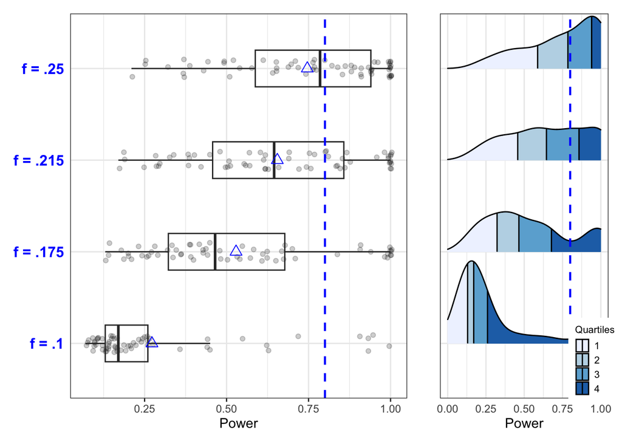

Figure 5: Distribution of power estimates for one-way multi-group design studies

```r
# combining the two
bp.1way + ridge.1way + plot_layout(ncol = 2, widths = c(2, 1))
```

#### Two-way factorial design (assuming 2 x 2)

```r
data.2way <- data.2way %>%
  mutate(cellsize = round(n_adjust/4, 0))
# n_adjust was a variable that adjusted the sample size for a fully-crossed design.
# That is, if design is 2 x 2 + 1 control, n_adjust = n/5 * 4

summary(data.2way$cellsize)
#cellsize: the cell size assuming 2 x 2 interaction for all studies
```

First of all, we reduced all factorial studies to a basic 2 x 2 design (k = 176). Cell size were recalculated as the total sample size divided by four. The median of the adjusted cell size was 52.5 (range: 6, 331). Overall, our procedure should lead to a more liberal estimate of the power for interaction effects, since power usually dissipates quickly as the design gets more complex.

In Figure 6, we depicted three scenarios of interaction effects, based on a baseline effect of a group difference of d = .43 (i.e., the ES for Factor 1 before Factor 2 is added to the study). F2 can interact with F1 in three ways: 1) reversal, 2) full attenuation, and 3) partial attenuation. To compute power for a 2 x 2 interaction, the effect size to be used depends on the shape of the interaction.

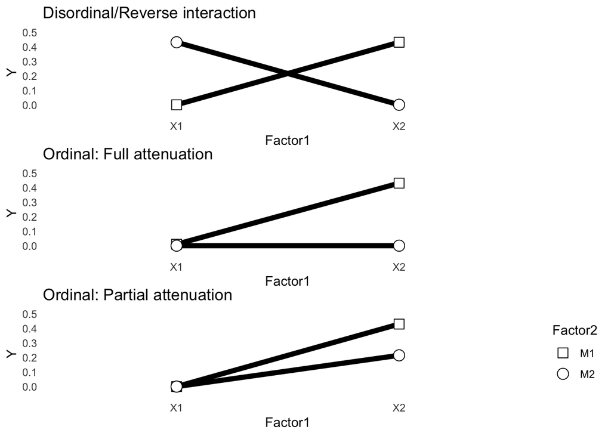

Figure 6: Patterns of Interaction Effects

```r
df <- data.frame(Factor1 = factor(c("X1", "X1", "X2", "X2")),
                 Factor2 = factor(c("M1", "M2", "M1", "M2")),
                 Y = c(0, 0.43, 0.43, 0))

p1 <- ggplot(data = df, aes(x = Factor1, y = Y,
                            group = Factor2, shape = Factor2)) +
  geom_line(size = 2) +
  scale_x_discrete(limits = c("X1", "X2")) +
  scale_y_continuous(limits = c(-0.05, 0.5)) +
  geom_point(size = 4, fill = "white") +
  scale_shape_manual(values = c(22, 21)) +
  theme_minimal() +
  theme(legend.position = "none", panel.grid = element_blank(),
        plot.margin = unit(c(0, 0, 0, 0), "null")) +
  ggtitle("Disordinal/Reverse interaction")


df2 <- data.frame(Factor1 = factor(c("X1", "X1", "X2", "X2")),
                  Factor2 = factor(c("M1", "M2", "M1", "M2")),
                  Y = c(0.01, 0, 0.43, 0))
p2 <- ggplot(data = df2, aes(x = Factor1, y = Y,
                             group = Factor2, shape = Factor2)) +
  geom_line(size = 2) +
  scale_x_discrete(limits = c("X1", "X2")) +
  scale_y_continuous(limits = c(-0.05, 0.5)) +
  geom_point(size = 4, fill = "white") +
  scale_shape_manual(values = c(22, 21)) +
  theme_minimal() +
  theme(legend.position = "none", panel.grid = element_blank(),
        plot.margin = unit(c(0, 0, 0, 0), "null")) +
  ggtitle("Ordinal: Full attenuation")

df3 <- data.frame(Factor1 = factor(c("X1", "X1", "X2", "X2")),
                  Factor2 = factor(c("M1", "M2", "M1", "M2")),
                  Y = c(0, 0, 0.43, 0.215))

p3 <- ggplot(data = df3, aes(x = Factor1, y = Y,
                             group = Factor2, shape = Factor2)) +
  geom_line(size = 2) +
  scale_x_discrete(limits = c("X1", "X2")) +
  scale_y_continuous(limits = c(-0.05, 0.5)) +
  geom_point(size = 4, fill = "white") +
  scale_shape_manual(values = c(22, 21)) +
  theme_minimal() +
  theme(panel.grid = element_blank(),
        plot.margin = unit(c(0, 0, 0, 0), "null")) +
  ggtitle("Ordinal: Partial attenuation")


p1 + p2 + p3 + plot_layout(nrow = 3, heights = c(1, 1, 1))
```

**Reversal**

```r
#| label: estimating power for reversal/disordinal interaction
#| echo: true
#| results: hide
#| warning: false
#| cache: true

# Step 4a-1: write a function based on `Superpower`
power.disord <- Vectorize(function(n) {
  design_result <- ANOVA_design(design = "2b*2b", n = n,
                                mu = c(0, 0.43, 0.43, 0), sd = 1,
                                plot = FALSE)
  power.main1 <- ANOVA_exact(design_result,
                             verbose = FALSE)$main_results$power[1]
  power.main2 <- ANOVA_exact(design_result,
                             verbose = FALSE)$main_results$power[2]
  power.int <- ANOVA_exact(design_result,
                           verbose = FALSE)$main_results$power[3]
  power.pc <- ANOVA_exact(design_result,
                          verbose = FALSE)$pc_results$power[1]
  power <- c(power.main1, power.main2, power.int, power.pc)
  return(power)
})

disord.output <- power.disord(data.2way$cellsize)

# Step 4a-2: creating a dataframe to store the results
disord.output2 <- rbind(disord.output, data.2way$cellsize, data.2way$id,
                        data.2way$year, data.2way$area1, data.2way$journal,
                        data.2way$b_cells_adjust, data.2way$factor)
disord.output2 <- as.data.frame(disord.output2)
row.names(disord.output2) <- c("Main1", "Main2", "Interaction", "Simple",
                               "cellsize", "id", "year", "area", "journal",
                               "cellnum", "factornum")

data.disord.power <- disord.output2 %>%
  t() %>%
  as.data.frame()  #transpose the dataframe

data.disord.power <- data.disord.power %>%
  dplyr::mutate_at(c("Main1", "Main2", "Interaction", "Simple", "cellsize",
                     "id", "cellnum", "factornum"), as.numeric) %>%
  mutate(across(where(is.numeric), round, digits = 2))
```

**Full attenuation**

```r
#| label: estimating power for ordinal interaction (full attenuation)
#| echo: true
#| results: hide
#| warning: false
#| cache: true

# Step 4b-1: write a function based on `Superpower`

power.ordfull <- Vectorize(function(n) {
  design_result <- ANOVA_design(design = "2b*2b", n = n,
                                mu = c(0, 0, 0.43, 0), sd = 1,
                                plot = FALSE)
  power.main1 <- ANOVA_exact(design_result,
                             verbose = FALSE)$main_results$power[1]
  power.main2 <- ANOVA_exact(design_result,
                             verbose = FALSE)$main_results$power[2]
  power.int <- ANOVA_exact(design_result,
                           verbose = FALSE)$main_results$power[3]
  power.pc <- ANOVA_exact(design_result,
                          verbose = FALSE)$pc_results$power[2]
  power <- c(power.main1, power.main2, power.int, power.pc)
  return(power)
})

ord.full.output <- power.ordfull(data.2way$cellsize)

# Step 4b-2: creating a dataframe to store the results

ord.full.output2 <- rbind(ord.full.output, data.2way$cellsize, data.2way$id,
                          data.2way$year, data.2way$area1, data.2way$journal,
                          data.2way$b_cells_adjust, data.2way$factor)
ord.full.output2 <- as.data.frame(ord.full.output2)
row.names(ord.full.output2) <- c("Main1", "Main2", "Interaction", "Simple",
                                 "cellsize", "id", "year", "area", "journal",
                                 "cellnum", "factornum")

data.ordfull.power <- ord.full.output2 %>%
  t() %>%
  as.data.frame()  #transpose the dataframe

data.ordfull.power <- data.ordfull.power  %>%
  dplyr::mutate_at(c("Main1", "Main2", "Interaction", "Simple", "cellsize",
                     "id", "cellnum", "factornum"), as.numeric) %>%
  mutate(across(where(is.numeric), round, digits = 2))
```

**Partial attenuation**

```r
#| label: estimating power for ordinal interaction (partial attenuation)
#| echo: true
#| results: hide
#| warning: false
#| cache: true

# Step 4c-1: write a function based on `Superpower`

power.partial <- Vectorize(function(n) {
  design_result <- ANOVA_design(design = "2b*2b", n = n,
                                mu = c(0, 0, 0.43, 0.215), sd = 1,
                                plot = FALSE)
  power.main1 <- ANOVA_exact(design_result,
                             verbose = FALSE)$main_results$power[1]
  power.main2 <- ANOVA_exact(design_result,
                             verbose = FALSE)$main_results$power[2]
  power.int <- ANOVA_exact(design_result,
                           verbose = FALSE)$main_results$power[3]
  power.pc <- ANOVA_exact(design_result,
                          verbose = FALSE)$pc_results$power[2]
  power <- c(power.main1, power.main2, power.int, power.pc)
  return(power)
})

ord.par.output <- power.partial(data.2way$cellsize)

# Step 4c-2: Creating a dataframe to store the results

ord.par.output2 <- rbind(ord.par.output, data.2way$cellsize, data.2way$id,
                         data.2way$year, data.2way$area1, data.2way$journal,
                         data.2way$b_cells_adjust, data.2way$factor)

ord.par.output2 <- as.data.frame(ord.par.output2)

row.names(ord.par.output2) <- c("Main1", "Main2", "Interaction", "Simple",
                                "cellsize", "id", "year", "area", "journal",
                                "cellnum", "factornum")

data.partial.power <- ord.par.output2 %>%
  t() %>%
  as.data.frame()  #transpose the dataframe

data.partial.power <- data.partial.power %>%
  dplyr::mutate_at(c("Main1", "Main2", "Interaction", "Simple", "cellsize",
                     "id", "cellnum", "factornum"), as.numeric) %>%
  mutate(across(where(is.numeric), round, digits = 2))
```

Figure 7 shows the distribution of power estimates for the three proptotypical interaction patterns.

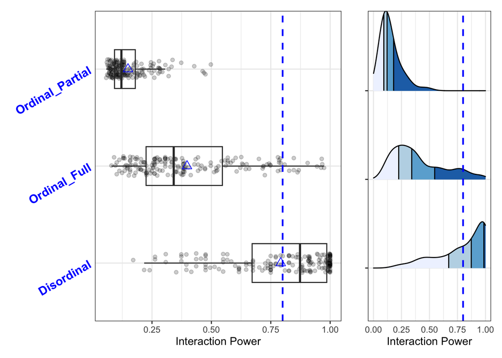

Figure 7: Distribution of power estimates for 2 x 2 factorial design studies

```r
# -- Step 4-3: combine results across three scenarios -----
data.2way.power <- rbind(data.disord.power, data.ordfull.power, data.partial.power)

data.2way.power$type <- c(rep("disordinal", 176), rep("ordinalfull", 176),
                          rep("ordinalpar", 176))

data.2way.power <- as_tibble(data.2way.power)

data.2way.power <- data.2way.power %>%
  mutate(int.power = Interaction/100, main.power = Main1/100,
         simple.power = Simple/100)

# -- Figure for interaction power ------

## boxplot
int1 <- ggplot(data.2way.power, aes(x = type, y = int.power)) +
  geom_point(alpha = 0.2, position = position_jitter(width = 0.1)) +
  geom_boxplot(width = 0.4, alpha = 0.2, fill = NA, outlier.shape = NA) +
  stat_summary(fun = "mean", geom = "point",
               shape = 2, size = 3, color = "blue") +
  scale_size_manual(values = c(0.5,  1), guide = "none") +
  scale_x_discrete(labels = c("Disordinal", "Ordinal_Full", "Ordinal_Partial")) +
  coord_flip() +
  labs(x = "", y = "Interaction Power") +
  geom_hline(yintercept = 0.8, linetype = "dashed",
             color = "blue", linewidth = 0.8) +
  theme_bw() + theme(axis.title.y = element_blank(),
                     axis.ticks.y = element_blank(),
                     axis.text.y = element_text(face = "bold", color = "blue",
                                                size = 12, angle = 30))

## ridgeplot
int2 <- data.2way.power %>%
  ggplot(aes(x = int.power, y = type, fill = factor(after_stat(quantile)))) +
  stat_density_ridges(geom = "density_ridges_gradient", calc_ecdf = TRUE,
                      quantiles = 4, quantile_lines = TRUE,
                      alpha = 0.8, scale = 0.9) +
  scale_x_continuous(breaks = seq(0, 1, 0.25), limits = c(0, 1)) +
  scale_fill_brewer(name = "Quartiles") +
  scale_size_manual(values = c(0.5, 1), guide = "none") +
  labs(y = "", x = "Interaction Power") +
  geom_vline(xintercept = 0.8, linetype = "dashed",
             color = "blue", linewidth = 0.8) +
  theme_bw() + theme(legend.position = "none") +
  theme(axis.ticks.x = element_blank()) +
  theme(legend.key.size = unit(0.8, "line")) +
  theme(legend.title = element_text(size = 8),
        axis.text.y = element_blank(), legend.text = element_text(size = 8))

int1 + int2 + plot_layout(ncol = 2, widths = c(2, 1))
```

## References

Elson, Malte, and Andrew K. Przybylski. 2017. “The Science of Technology and Human Behavior.” *Journal of Media Psychology* 29 (1): 1–7. https://doi.org/10.1027/1864-1105/a000212.

Fraley, R. Chris, and Simine Vazire. 2014. “The N-Pact Factor: Evaluating the Quality of Empirical Journals with Respect to Sample Size and Statistical Power.” Edited by Christos A. Ouzounis. *PLoS ONE* 9 (10): e109019. https://doi.org/10.1371/journal.pone.0109019.

Lakens, Daniël. 2022. “Sample Size Justification.” *Collabra: Psychology* 8 (1). https://doi.org/10.1525/collabra.33267.

Nuijten, Michèle B., Marcel A. L. M. van Assen, Hilde E. M. Augusteijn, Elise A. V. Crompvoets, and Jelte M. Wicherts. 2020. “Effect Sizes, Power, and Biases in Intelligence Research: A Meta-Meta-Analysis.” *Journal of Intelligence* 8 (4): 36. https://doi.org/10.3390/jintelligence8040036.

Rains, Stephen A., Timothy R. Levine, and Rene Weber. 2018. “Sixty Years of Quantitative Communication Research Summarized: Lessons from 149 Meta-Analyses.” *Annals of the International Communication Association* 42 (2): 105–24. https://doi.org/10.1080/23808985.2018.1446350.

Schäfer, Thomas, and Marcus A. Schwarz. 2019. “The Meaningfulness of Effect Sizes in Psychological Research: Differences Between Sub-Disciplines and the Impact of Potential Biases.” *Frontiers in Psychology* 10 (April). https://doi.org/10.3389/fpsyg.2019.00813.

## Footnotes

[^1]: Our analysis was essentially a sensitivity power analysis, that is, to estimate the level of power for an assumed effect size given the known sample size. Whereas for primary studies, sample size planning using power analysis should be based on a study-specific effect size for the design and primary test(s) ((Lakens 2022), it is beyond the scope of this meta-assessment project to retrospectively postulate a reasonable effect size considering the specific design and context of each study
[^2]: These benchmarks are more reasonable heuristics for describing small, medium, and large effects: $d$ = 0.20, 0.35, and = 0.50, respectively. These values correspond to Cohen’s $f$ of 0.10, 0.175, and 0.25 (and Pearson correlation coefficients of $r$ = .10, .17, and .24, and partial eta squared of $η2$ = .01, .03, .06).